# Case study on text classification

```python
#   packages
import gc
gc.collect()
import os
import warnings
warnings.filterwarnings("ignore")
import time

from tqdm import tqdm
import numpy as np
import pandas as pd
import matplotlib.pyplot as plt

from nltk.corpus import stopwords
stop_words_list = stopwords.words("english")
import string
punctuation = list(string.punctuation)

import nltk
#nltk.download('punkt')
#nltk.download('wordnet')
from nltk.stem import WordNetLemmatizer

import gensim
import pyLDAvis

from collections import Counter
import seaborn as sns
import matplotlib.pyplot as plt
from matplotlib import rcParams

from wordcloud import WordCloud, STOPWORDS
stopwords = set(STOPWORDS)

from sklearn.model_selection import train_test_split
from sklearn.feature_extraction.text import CountVectorizer

#   classification packages
from sklearn.feature_extraction.text import HashingVectorizer   #To guarantee that the features space remains the same over time we leverage a HashingVectorizer that will project each example into the same feature space. This is especially useful in the case of text classification where new features (words) may appear in each batch.
from sklearn.linear_model import SGDClassifier  #Linear classifiers with Stochastic Gradient Descent (SGD) learning Default gives a linear SVM.
from sklearn.linear_model import PassiveAggressiveClassifier
from sklearn.linear_model import Perceptron
from sklearn.naive_bayes import MultinomialNB
from sklearn.naive_bayes import ComplementNB

## prediction score
from sklearn.metrics import accuracy_score
from sklearn.metrics import balanced_accuracy_score
from sklearn.metrics import cohen_kappa_score
from sklearn.metrics import precision_score
from sklearn.metrics import recall_score
from sklearn.metrics import f1_score
from sklearn.metrics import confusion_matrix, ConfusionMatrixDisplay
```

```python
YELP=pd.read_feather(os.path.join("data", "YELP_texToken.feather"))[["stars", "textToken", "Token"]]
```

```python
YELP
```

|  | stars | textToken | Token |
| --- | --- | --- | --- |
| 0 | 5 | overdue review good sandwich shop cle small me... | [overdue, review, good, sandwich, shop, cle, s... |
| 1 | 3 | not | [not] |
| 2 | 1 | not get wrong food ok compare day go black ang... | [not, get, wrong, food, ok, compare, day, go, ... |
| 3 | 5 | great pizza annual visit first pizza town prob... | [great, pizza, annual, visit, first, pizza, to... |
| 4 | 5 | hell kitchen avocado bomb bacon bomb swiss che... | [hell, kitchen, avocado, bomb, bacon, bomb, sw... |
| ... | ... | ... | ... |
| 5257573 | 5 | burrito elchino | [burrito, elchino] |
| 5257574 | 5 | special pasta squid ink | [special, pasta, squid, ink] |
| 5257575 | 5 | package | [package] |
| 5257576 | 1 | shutter | [shutter] |
| 5257577 | 5 | good massge come day lavery good good good | [good, massge, come, day, lavery, good, good, ... |

5257578 rows × 3 columns

```python
labels = YELP.stars.tolist()
category_list = YELP.stars.unique()
YELP_sub, X_test, YELP_sub_y, y_test = train_test_split(YELP, labels, train_size=0.01, stratify=labels, random_state=123)
```

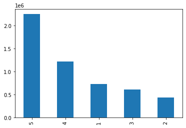

```python
fig=YELP.stars.value_counts().plot(kind='bar')
labelFig=fig.get_figure()
```

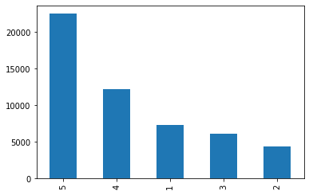

```python
fig=YELP_sub.stars.value_counts().plot(kind='bar')
labelFig=fig.get_figure()
```

## Exploratory Data Analysis

#### Analyzing text statistics

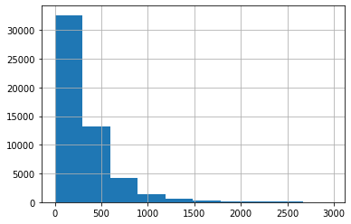

```python
YELP_sub['textLen']=YELP_sub.textToken.str.len()
YELP_sub['textLen'].hist()
```

The histogram shows that YELP text range from 1 to 2500 characters and generally, it is between 1 to 500 characters. Let's check for each label...

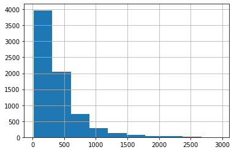

```python
YELP_sub['textLen'][YELP_sub.stars==1].hist()
```

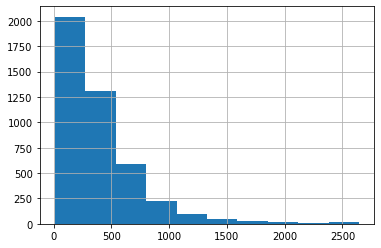

```python
YELP_sub['textLen'][YELP_sub.stars==2].hist()
```

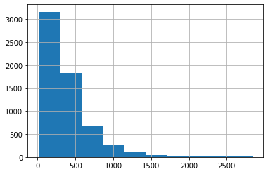

```python
YELP_sub['textLen'][YELP_sub.stars==3].hist()
```

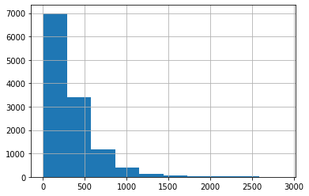

```python
YELP_sub['textLen'][YELP_sub.stars==4].hist()
```

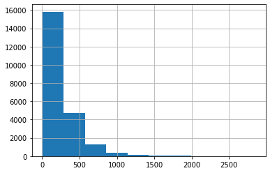

```python
YELP_sub['textLen'][YELP_sub.stars==5].hist()
```

Let's plot the number of words appearing in each text

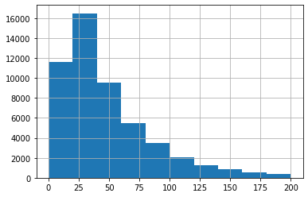

```python
YELP_sub["Token"].str.len().hist(range=[0, 200])
```

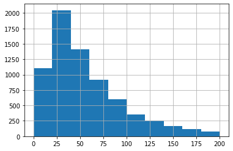

```python
YELP_sub["Token"][YELP_sub.stars==1].str.len().hist(range=[0, 200])
```

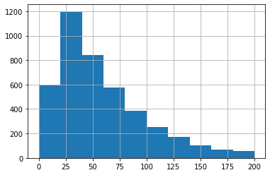

```python
YELP_sub["Token"][YELP_sub.stars==2].str.len().hist(range=[0, 200])
```

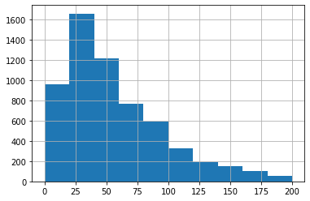

```python
YELP_sub["Token"][YELP_sub.stars==3].str.len().hist(range=[0, 200])
```

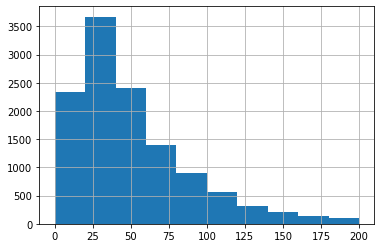

```python
YELP_sub["Token"][YELP_sub.stars==4].str.len().hist(range=[0, 200])
```

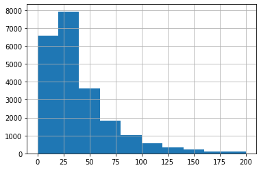

```python
YELP_sub["Token"][YELP_sub.stars==5].str.len().hist(range=[0, 200])
```

let’s check the average word length in each sentence

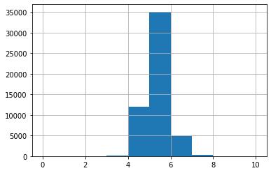

```python
YELP_sub["Token"].\
   apply(lambda x : [len(i) for i in x]). \
   map(lambda x: np.mean(x)).hist(range=[0, 10])
```

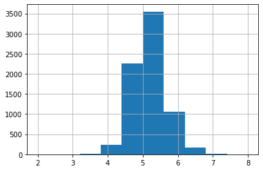

```python
YELP_sub["Token"][YELP_sub.stars==1].\
   apply(lambda x : [len(i) for i in x]). \
   map(lambda x: np.mean(x)).hist(range=[2, 8])
```

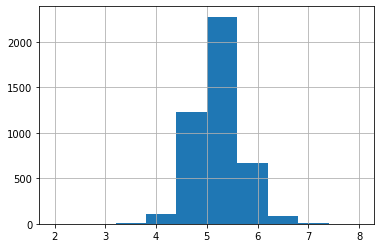

```python
YELP_sub["Token"][YELP_sub.stars==2].\
   apply(lambda x : [len(i) for i in x]). \
   map(lambda x: np.mean(x)).hist(range=[2, 8])
```

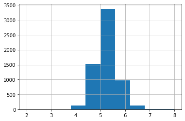

```python
YELP_sub["Token"][YELP_sub.stars==3].\
   apply(lambda x : [len(i) for i in x]). \
   map(lambda x: np.mean(x)).hist(range=[2, 8])
```

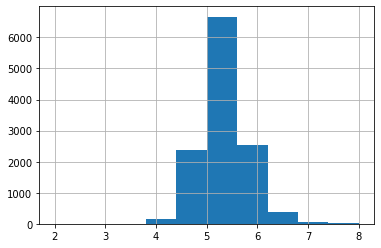

```python
YELP_sub["Token"][YELP_sub.stars==4].\
   apply(lambda x : [len(i) for i in x]). \
   map(lambda x: np.mean(x)).hist(range=[2, 8])
```

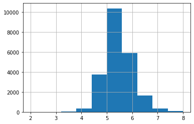

```python
YELP_sub["Token"][YELP_sub.stars==5].\
   apply(lambda x : [len(i) for i in x]). \
   map(lambda x: np.mean(x)).hist(range=[2, 8])
```

let’s inspect which words occur frequently: we will use the counter function from the collections library to count and store the occurrences of each word in a list of tuples.

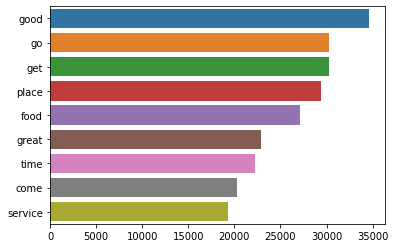

```python
corpus=[]
corpus=[word for i in YELP_sub.Token for word in i]

counter=Counter(corpus)
most=counter.most_common()

x, y= [], []
for word,count in most[:10]:
    x.append(word)
    y.append(count)

sns.barplot(x=y,y=x)
```

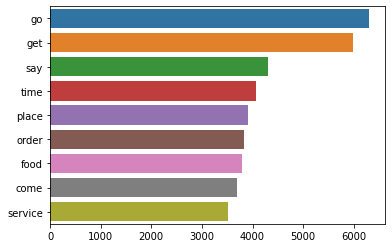

```python
corpus=[]
corpus=[word for i in YELP_sub.Token[YELP_sub.stars==1] for word in i]

counter=Counter(corpus)
most=counter.most_common()

X, Y= [], []
for word,count in most[:10]:
    X.append(word)
    Y.append(count)

sns.barplot(x=Y,y=X)
```

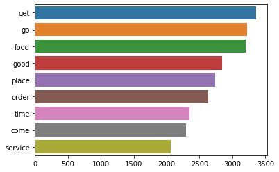

```python
corpus=[]
corpus=[word for i in YELP_sub.Token[YELP_sub.stars==2] for word in i]

counter=Counter(corpus)
most=counter.most_common()

X, Y= [], []
for word,count in most[:10]:
    X.append(word)
    Y.append(count)

sns.barplot(x=Y,y=X)
```

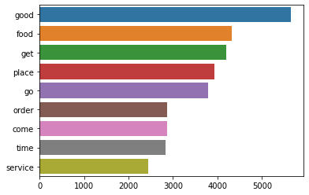

```python
corpus=[]
corpus=[word for i in YELP_sub.Token[YELP_sub.stars==3] for word in i]

counter=Counter(corpus)
most=counter.most_common()

X, Y= [], []
for word,count in most[:10]:
    X.append(word)
    Y.append(count)

sns.barplot(x=Y,y=X)
```